# Test your R install!

This is an R install test document. We compile it in a way that the code will not be visible, you will just have the output. Imagine this is a report, and your boss is deeply uninterested in the code. But she very much wants to see the results!

## Load data from a non-default package

Here we loaded data (Galton 1886 parents/children height data) from package *UsingR*. You probably have to install that package.

## Use **dplyr** commands

Here we use dplyr to convert inches to centimeters. In the original data the height is given in inches. If it works, you have a functioning dplyr installation.

## Do some plotting

Finally, here is the plot of the data. The dots should be centered around 170..180 cm for both horizontally (fathers) and vertically (sons). The chunk option `message=FALSE` should remove the message "geom_smooth() using formula…`. You should *not* see this message in the final document.

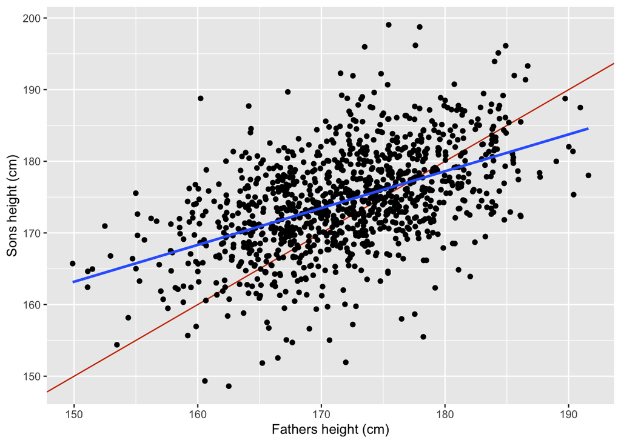

The black dots depict parent-child pairs (although the data claims it is about fathers and sons, Galton was in fact also using mothers and daughters). The red line is one-to-one relationship, meaning that one cm taller parents have in average one cm taller children. As the blue regression line shows, this is not at all the case. Taller parents have taller children, but not as much above the mean as parents. This is what Galton (1886) called “regression to mean”.

## Submission

If unsure, feel free to submit the lab and we’ll tell you if you submitted the right things. You should submit:

- rmd file (this one)
- the final html (or pdf)

and the same for notebook:

- notebook .ipynb
- final html (or pdf)